# Qualtrics Import Workshop

Ungson, Nick D.

Created: 2018-11-26 | *Last updated: 2018-12-05 12:38:01*

In this document, I will walk you through my process of using R to (1) **Import and tidy** raw Qualtrics data, (2) **Calculate** variables, and (3) **Analyze** that data.

This document contains code snippets and their respective output, but you can easily copy and paste the code below and adapt it for your own data and analyses!

# Preliminaries

## Study Design and Variables

The sample data come from a **3** (Tweet: animal vs. funny vs. baseline) x **2** (Animal: cat vs. dog) mixed design study.

Independent Variables:

- **Tweet** was the between-subjects variable: Participants either viewed (1) funny animal-themed tweets [*Animal* condition], (2) funny non-animal funny tweets [*Funny* condition], or (3) no tweets [*Baseline*].
- **Animal** was the within-subjects variable. Participants completed the shortened Big Five Inventory (BFI, see below) in the third-“person” with regards to a (1) *dog* and (2) *cat*, in counterbalanced order.

Dependent Variable: The BFI has five subscales: **Openness to Experience, Conscientiousness, Extraversion, Agreeableness, Neuroticism**. Extraversion and Agreeableness were measured using three items; the remaining subscales were measured using two items. Each item was scored on a scale of 1 to 5, with higher scores indicating “more” of that trait.

Other Measured Variables: For each of the six tweets (if participants were assigned to *Animal* or *Funny* conditions), participants answered three questions regarding perceived funniness, likilihood to “fav”, and likelihood to “share” that tweet on a scale from 1 (*not at all funny*/*not at all likely*) to 5 (*extremely funny*/*extremely likely*).

## Load R Packages

First, load the `tidyverse` package. If you don’t have this package installed, running `install.packages("tidyverse")` (which is commented out in the code below) will install the package. You only need to install each package once, but you need to load the package using `require()` or `library()` (they’re the same) every time you start a new R session. The `tidyverse` package includes and automatically loads other cool packages, like ``ggplot` and `dplyr`, so you don’t have to individually load those if you are loading the entire “tidyverse,” so to speak.

```r
#install.packages("tidyverse")
require(tidyverse)
```

# Import and Tidy

## Import raw data

First, import the “fresh” raw data from Qualtrics and save as a dataframe called `raw`. As long as the current R Markdown document is in the same directory as `"raw qualtrics data.csv"`, the full file name is all you need to put in `read.csv()`.

```r
raw <- read.csv("raw qualtrics data.csv",
                header = TRUE,
                stringsAsFactors = FALSE)
```

Before moving on, convert `raw` to a tibble (pun on “table”?), which works much more nicely than data frames with the `dplyr` package (which is automatically loaded as part of the `tidyverse`). ([For more info on tibbles](https://cran.r-project.org/web/packages/tibble/vignettes/tibble.html)).

```r
# coerce to tibble
raw <- as_tibble(raw)
```

## Tidy

**Remove superfluous rows** First, let’s take a look at the first 10 rows and first 5 columns of `raw`. You can click the arrows in the output below to scroll through the columns.

```r
raw[1:10, 1:5]
```

| StartDate | EndDate | Status | IPAddress | Progress |
| --- | --- | --- | --- | --- |
| Start Date | End Date | Response Type | IP Address | Progress |
| {"ImportId":"startDate","timeZone":"America/New_York"} | {"ImportId":"endDate","timeZone":"America/New_York"} | {"ImportId":"status"} | {"ImportId":"ipAddress"} | {"ImportId":"progress"} |
| 2018-11-19 13:43:56 | 2018-11-19 13:47:54 | 0 | 128.180.132.125 | 100 |
| 2018-11-19 13:52:30 | 2018-11-19 13:59:47 | 0 | 128.180.132.247 | 100 |
| 2018-11-19 14:03:10 | 2018-11-19 14:05:22 | 0 | 64.121.123.36 | 100 |
| 2018-11-19 14:05:55 | 2018-11-19 14:11:28 | 0 | 128.180.107.57 | 100 |
| 2018-11-19 14:13:10 | 2018-11-19 14:17:11 | 0 | 128.180.96.119 | 100 |
| 2018-11-19 14:17:16 | 2018-11-19 14:22:58 | 0 | 70.167.95.125 | 100 |
| 2018-11-19 14:24:51 | 2018-11-19 14:28:29 | 0 | 149.31.125.184 | 100 |
| 2018-11-19 14:39:23 | 2018-11-19 14:43:37 | 0 | 149.31.82.101 | 100 |

Something that should jump out at you is that rows 1 and 2 contain unnecessary information. Row 1 simply repeats the question labels; although for later columns, this row contains question wording and you could need them for some studies. Row 2 contains metadata for each question. For our purposes, you don’t want either of them. **Remove rows 1 and 2** by using indexing (`[]`) and using the negative sign (`-`) to exclude rows 1 and 2 (`-c(1:2)`) and overwrite `raw`.

```r
# remove 1st and 2nd row (unnecessary qualtrics metadata)
raw <- raw[-c(1:2), ]
```

**Remove superfluous columns** Next, let’s take a look at the column headings in `raw`.

```r
colnames(raw)
```

```
##  [1] "StartDate"             "EndDate"
##  [3] "Status"                "IPAddress"
##  [5] "Progress"              "Duration..in.seconds."
##  [7] "Finished"              "RecordedDate"
##  [9] "ResponseId"            "RecipientLastName"
## [11] "RecipientFirstName"    "RecipientEmail"
## [13] "ExternalReference"     "LocationLatitude"
## [15] "LocationLongitude"     "DistributionChannel"
## [17] "UserLanguage"          "anim1_1"
## [19] "anim1_2"               "anim1_3"
## [21] "anim2_1"               "anim2_2"
## [23] "anim2_3"               "anim3_1"
## [25] "anim3_2"               "anim3_3"
## [27] "anim4_1"               "anim4_2"
## [29] "anim4_3"               "anim5_1"
```

[output cut: 27 more lines]

Importantly, since you are now excluding variables, create a new data frame called `data` and use the `select()` function to choose which variables to keep from `raw` and to rename when necessary (e.g., `$Duration..in.seconds.` is renamed as `$time_sec`). This way, the raw data remains relatively untouched in case you need to go back to it later.

*Note*: The code below uses the pipe operator `%>%` from the `dplyr` package. Basically, the operator takes whatever came before it (below, the `raw` data) and subjects it to what comes after: selecting variables using `select()`. One great thing about `dplyr` is you won’t have to use the `$` operator to identify variables as much.

Check out the following guides on `dplyr` that I return to *all the time*:

- [Introduction to dplyr](https://cran.r-project.org/web/packages/dplyr/vignettes/dplyr.html)
- [dplyr tutorial by MIT Biomedical Data Science](http://genomicsclass.github.io/book/pages/dplyr_tutorial.html)

```r
data <- raw %>%
  select(progress = Progress,
         time_sec = Duration..in.seconds.,
         # select all variables between $anim1_1 and $anim6_3
         anim1_1:anim6_3,
         # select all variables that contain "fun"
         contains("fun"),
         # select all dog and cat variables in order I specify
         dog_extra1r, dog_extra2, dog_extra3,
         dog_agree1, dog_agree2r, dog_agree3,
         dog_cons1r, dog_cons2,
         dog_neur1r, dog_neur2,
         dog_open1r, dog_open2,
         cat_extra1r, cat_extra2, cat_extra3,
         cat_agree1, cat_agree2r, cat_agree3,
         cat_cons1r, cat_cons2,
         cat_neur1r, cat_neur2,
         cat_open1r, cat_open2,
         # select all variables between age and condition
         age:condition)
```

Great! Now we have a working `data` dataframe that we can start to mess around with. Remember, you can always do stuff like `colnames(data)`, `glimpse(data)`, or `str(data)` to investigate anything further.

```r
# look at variables in 'data'
colnames(data)
```

```
##  [1] "progress"           "time_sec"           "anim1_1"
##  [4] "anim1_2"            "anim1_3"            "anim2_1"
##  [7] "anim2_2"            "anim2_3"            "anim3_1"
## [10] "anim3_2"            "anim3_3"            "anim4_1"
## [13] "anim4_2"            "anim4_3"            "anim5_1"
## [16] "anim5_2"            "anim5_3"            "anim6_1"
## [19] "anim6_2"            "anim6_3"            "fun1_1"
## [22] "fun1_2"             "fun1_3"             "fun2_1"
## [25] "fun2_2"             "fun2_3"             "fun3_1"
## [28] "fun3_2"             "fun3_3"             "fun4_1"
## [31] "fun4_2"             "fun4_3"             "fun5_1"
## [34] "fun5_2"             "fun5_3"             "fun6_1"
## [37] "fun6_2"             "fun6_3"             "dog_extra1r"
## [40] "dog_extra2"         "dog_extra3"         "dog_agree1"
## [43] "dog_agree2r"        "dog_agree3"         "dog_cons1r"
## [46] "dog_cons2"          "dog_neur1r"         "dog_neur2"
## [49] "dog_open1r"         "dog_open2"          "cat_extra1r"
## [52] "cat_extra2"         "cat_extra3"         "cat_agree1"
## [55] "cat_agree2r"        "cat_agree3"         "cat_cons1r"
## [58] "cat_cons2"          "cat_neur1r"         "cat_neur2"
## [61] "cat_open1r"         "cat_open2"          "age"
## [64] "gender"             "gender_fr"          "lehigh_status"
## [67] "check_manipulation" "condition"
```

As part of importing data, R sometimes makes choices about what kind of data type each variable is (e.g., numeric, string, etc.), so the code below will ensure that the variables I *want* to be numeric are actually recognized as numeric by R. We’ll do this using the now-familiar pipe operator (`%>%`) and `mutate_at()` ([source](https://twitter.com/SuzanBaert/status/984054401374523392)). For this example, I’m going to make everything numeric except `$gender_fr`, a free response item on which participants could specify their gender.

```r
# coerce variables to numeric using column index
data <- data %>%
  mutate_at(vars(1:64, 66:68), as.numeric)
```

## Exclude subjects

For the current study, we will exclude any participants who **did not complete the study**. First, use `table()` to look at the frequencies of `$progress`. (*Note*: `table()` is my go-to function for getting frequencies; e.g., gender)

```r
# frequency of progress
table(data$progress)
```

```
##
##   1   2  31  35  40  44  59  75  91  99 100
##   1   1   3   2   2   1  10   6   1  12 105
```

105 participants completely finished (`$progress == 100`), 12 got 99% of the way through, and then there’s a smattering of others. This is something you’ll have to decide for your studies; for now, exclude anyone who was below 99% completion.

Notice that the code below uses the pipe operator `%>%` from the `dplyr` package again. However instead of using `select()` to identify variables/columns to keep/drop, use `filter()` to identify participants/rows to keep/drop:

```r
# keep only participants with at least 99% completion
data <- data %>%
  filter(progress >= 99)
```

Next, exclude any participants **failed the manipulation check**; participants were asked to identify which tweet condition they were exposed to. Before that, though, let’s see how many participants failed the check using `nrow()` and indexing. Note that you must use `data$` before variables because we are not using `dplyr` for this:

```r
# in how many rows does check_manipulation not equal condition?
nrow(data[data$check_manipulation != data$condition, ])
```

```
## [1] 7
```

```r
data <- data %>%
  filter(check_manipulation == condition)
```

## Add participant number

Next, add a unique participant number variable. If your own study already includes a participant number variable or unique identifier, this would be unnecessary. But having a unique subject variable for each participant is crucial for calculating participant-level variables (e.g., scale means). You’ll be using another `dplyr` verb: `mutate()`, which is used to compute new variables:

```r
data <- data %>%
  mutate(participant = 1:n())
```

## Concatenate across between-subjects variables

The last thing to do tidy this data is to deal with missing values (also known as `NA`s) that have arisen due to between-subjects variables. For example, participants in the Animal tweet condition made ratings about the animal tweets they saw (e.g., `$anim1_1`, `$anim1_2`) but did not answer–and therefore have missing values–for all tweet items corresponding to the Funny tweet condition (e.g., `$fun1_1`, `$fun1_2`). As a demonstration of this:

```r
# sample of NA's across animal vs. funny tweet items
data[1:4, c(69, 3:5, 21:22)]
```

| participant | anim1_1 | anim1_2 | anim1_3 | fun1_1 | fun1_2 |
| --- | --- | --- | --- | --- | --- |
| 1 | NA | NA | NA | 2 | 1 |
| 2 | 4 | 4 | 2 | NA | NA |
| 3 | NA | NA | NA | NA | NA |
| 4 | 4 | 2 | 3 | NA | NA |

Here we can see that participant #1 was in the Funny condition, participant #2 was in the Animal condition, and participant #3 was in the Baseline condition (`NA` for all tiems). To concatenate across these columns and create new variables, use `coalesce()` within the now-familiar `mutate()` function. The code below may look clunky, and I’m sure you could write a function to this more elegantly, but it definitely works.

```r
data <- data %>%
  mutate(tweet1_1 = coalesce(anim1_1, fun1_1),
         tweet1_2 = coalesce(anim1_2, fun1_2),
         tweet1_3 = coalesce(anim1_3, fun1_3),
         tweet2_1 = coalesce(anim2_1, fun2_1),
         tweet2_2 = coalesce(anim2_2, fun2_2),
         tweet2_3 = coalesce(anim2_3, fun2_3),
         tweet3_1 = coalesce(anim3_1, fun3_1),
         tweet3_2 = coalesce(anim3_2, fun3_2),
         tweet3_3 = coalesce(anim3_3, fun3_3),
         tweet4_1 = coalesce(anim4_1, fun4_1),
         tweet4_2 = coalesce(anim4_2, fun4_2),
         tweet4_3 = coalesce(anim4_3, fun4_3),
         tweet5_1 = coalesce(anim5_1, fun5_1),
         tweet5_2 = coalesce(anim5_2, fun5_2),
         tweet5_3 = coalesce(anim5_3, fun5_3),
         tweet6_1 = coalesce(anim6_1, fun6_1),
         tweet6_2 = coalesce(anim6_2, fun6_2),
         tweet6_3 = coalesce(anim6_3, fun6_3))

# if you want to check out the variables
#colnames(data)
```

## Tidy: Done!

**Okay the data is now pretty tidy**. Many of the operations above were done separately to help explain the logic, but you could easily string many of the dplyr commands together depending on your needs/wants/desires. The code below would produce the exact same tidied data set.

```r
data <- raw %>%
  select(progress = Progress,
         time_sec = Duration..in.seconds.,
         anim1_1:anim6_3,
         contains("fun"),
         dog_extra1r, dog_extra2, dog_extra3,
         dog_agree1, dog_agree2r, dog_agree3,
         dog_cons1r, dog_cons2,
         dog_neur1r, dog_neur2,
         dog_open1r, dog_open2,
         cat_extra1r, cat_extra2, cat_extra3,
         cat_agree1, cat_agree2r, cat_agree3,
         cat_cons1r, cat_cons2,
         cat_neur1r, cat_neur2,
         cat_open1r, cat_open2,
         age:condition) %>%
  mutate_at(vars(1:64, 66:68), as.numeric) %>%
  filter(progress >= 99) %>%
  filter(check_manipulation == condition) %>%
  mutate(participant = 1:n(),
         tweet1_1 = coalesce(anim1_1, fun1_1),
         tweet1_2 = coalesce(anim1_2, fun1_2),
         tweet1_3 = coalesce(anim1_3, fun1_3),
         tweet2_1 = coalesce(anim2_1, fun2_1),
         tweet2_2 = coalesce(anim2_2, fun2_2),
         tweet2_3 = coalesce(anim2_3, fun2_3),
         tweet3_1 = coalesce(anim3_1, fun3_1),
         tweet3_2 = coalesce(anim3_2, fun3_2),
         tweet3_3 = coalesce(anim3_3, fun3_3),
         tweet4_1 = coalesce(anim4_1, fun4_1),
         tweet4_2 = coalesce(anim4_2, fun4_2),
         tweet4_3 = coalesce(anim4_3, fun4_3),
         tweet5_1 = coalesce(anim5_1, fun5_1),
         tweet5_2 = coalesce(anim5_2, fun5_2),
         tweet5_3 = coalesce(anim5_3, fun5_3),
         tweet6_1 = coalesce(anim6_1, fun6_1),
         tweet6_2 = coalesce(anim6_2, fun6_2),
         tweet6_3 = coalesce(anim6_3, fun6_3))
```

# Calculate Variables

Now, it’s time to calculate some variables:

- BFI: Extraversion (cat and dog)
- BFI: Openness to Experience (cat and dog)
- BFI: Conscientiousness (cat and dog)
- BFI: Neuroticism (cat and dog)
- BFI: Agreeableness (cat and dog)
- Positive evaluation of tweets

## BFI dimensions

**Extraversion** was measured for each animal using 3 items:

- `$dog_extra1r` (reverse-coded)
- `$dog_extra2`
- `$dog_extra3`

Below, for each participant, calculate the mean dog extraversion by averaging these three items in a new variable `$dog_extra`. Some things to note:

- `group_by()` is used to ensure that whatever comes afterwards is applied separately to each “group” specified. In other words, if you did not include `group_by(participant)`, you would calculate the grand dog extra version of mean across all participants (i.e., everyone would have the same score). By including `group_by(participant)`, you make sure that the mean calculation occurs for every “group” (participant). By this logic, you could also use `group_by(condition)` and this code would give you the mean dog extraversion for each of the three tweet conditions.
- `(6 - dog_extra1r)` refers to the reverse-scoring of that item
- `na.rm = TRUE` tells R to ignore missing values. Otherwise, if a participant happened to skip one dog extraversion item, no mean would be calculated and `NA` would be returned for that participant. This way, R calculates the mean from all available data.
- The code below also calculates cat extraversion, `$cat_extra`, using the same logic; remmber, multiple variables can be created inside `mutate()` as long as you separate with commas!

```r
data <- data %>%
  group_by(participant) %>%
  mutate(dog_extra = mean((6 - dog_extra1r), dog_extra2, dog_extra3, na.rm = TRUE),
         cat_extra = mean((6 - cat_extra1r), cat_extra2, cat_extra3, na.rm = TRUE))
```

**Neuroticism** was measured for each animal using 2 items:

- `$dog_neur1r` (reverse-coded)
- `$dog_neur2`

Create means in the exact same way:

```r
data <- data %>%
  group_by(participant) %>%
  mutate(dog_neur = mean((6 - dog_neur1r), dog_neur2, na.rm = TRUE),
         cat_neur = mean((6 - cat_neur1r), cat_neur2, na.rm = TRUE))
```

…you could then easily do the same thing for the rest of the BFI variables:

```r
data <- data %>%
  group_by(participant) %>%
  mutate(dog_agree = mean((6 - dog_agree2r), dog_agree1, dog_agree3, na.rm = TRUE),
         cat_agree = mean((6 - cat_agree2r), cat_agree1, cat_agree3, na.rm = TRUE),
         dog_cons = mean((6 - dog_cons1r), dog_cons2, na.rm = TRUE),
         cat_cons = mean((6 - cat_cons1r), cat_cons2, na.rm = TRUE),
         dog_open = mean((6 - dog_open1r), dog_open2, na.rm = TRUE),
         cat_open = mean((6 - cat_open1r), cat_open2, na.rm = TRUE))
```

## Tweet evaluation

```r
data <- data %>%
  group_by(participant) %>%
  mutate(tweet_eval = mean(tweet1_1, tweet1_2, tweet1_3,
                           tweet2_1, tweet2_2, tweet2_3,
                           tweet3_1, tweet3_2, tweet3_3,
                           tweet4_1, tweet4_2, tweet4_3,
                           tweet5_1, tweet5_2, tweet5_3,
                           tweet6_1, tweet6_2, tweet6_3, na.rm = TRUE))
```

## Re-order variables

This is not strictly necessary, but I like to do one last “tidying” measure before starting with analyses: remove now-unnecessary variables (e.g., between-subjects items that are useless now that we’ve used `coalesce()` to concatenate; progress) and order variables to my liking. Remember, the order of variables passed through `select()` is the order they will be placed into resulting data.

```r
data <- data %>%
  select(participant, condition,
         # all calculated variables
         dog_extra:tweet_eval,
         # demographics, etc.
         time_sec, age:lehigh_status,
         # individual scale items (retain for reliability analyses)
         tweet1_1:cat_open)
```

Take a moment to apreciate your clean data set:

```r
colnames(data)
```

```
##  [1] "participant"   "condition"     "dog_extra"     "cat_extra"
##  [5] "dog_neur"      "cat_neur"      "dog_agree"     "cat_agree"
##  [9] "dog_cons"      "cat_cons"      "dog_open"      "cat_open"
## [13] "tweet_eval"    "time_sec"      "age"           "gender"
## [17] "gender_fr"     "lehigh_status" "tweet1_1"      "tweet1_2"
## [21] "tweet1_3"      "tweet2_1"      "tweet2_2"      "tweet2_3"
## [25] "tweet3_1"      "tweet3_2"      "tweet3_3"      "tweet4_1"
## [29] "tweet4_2"      "tweet4_3"      "tweet5_1"      "tweet5_2"
## [33] "tweet5_3"      "tweet6_1"      "tweet6_2"      "tweet6_3"
```

# Optional: Export Data

At this point, you may want to export `data` in it’s cleaned form, perhaps as a .csv file. You can use the `write.csv()` function for that ([source](http://rprogramming.net/write-csv-in-r/)). Something to remember is to set `row.names = FALSE` to prevent R from creating a new column with row numbers in your new .csv file. Besides, we already have `$participant` anyway!

Below is an example of how you might go about it:

```r
write.csv(data,
          file = "2018-12-05 clean data.csv",
          row.names = fALSE)
```

# Analyze

## Descriptives

There are few of ways to get descriptive statistics for your variables. I’ll demonstrate a couple of them here.

You can get them “individually”, like so:

```r
mean(data$age)
```

```
## [1] 32.06364
```

```r
sd(data$age)
```

```
## [1] 10.05971
```

You can use functions to return several statistics. For example, the `stat.desc()` function in the `pastecs` package:

```r
#install.packages("pastecs")
require(pastecs)
stat.desc(data$age)
```

```
##      nbr.val     nbr.null       nbr.na          min          max
##  110.0000000    0.0000000    0.0000000   20.0000000   72.0000000
##        range          sum       median         mean      SE.mean
##   52.0000000 3527.0000000   30.0000000   32.0636364    0.9591556
## CI.mean.0.95          var      std.dev     coef.var
##    1.9010153  101.1977481   10.0597091    0.3137420
```

A fun thing about arrays like the one `stat.desc()` spits out is that you can use `[]` to index and pull out specific values. For example, if you wanted to *just* return the mean of `$age`, you know that mean is the 9th thing in that object, so just pull it out!

```r
# see what's "inside" stat.desc(data$age)
names(stat.desc(data$age))
```

```
##  [1] "nbr.val"      "nbr.null"     "nbr.na"       "min"
##  [5] "max"          "range"        "sum"          "median"
##  [9] "mean"         "SE.mean"      "CI.mean.0.95" "var"
## [13] "std.dev"      "coef.var"
```

```r
# pull out mean
stat.desc(data$age)[9]
```

```
##     mean
## 32.06364
```

Another way is using the `describe()` function from the `psych` package:

```r
require(psych)
describe(data$age)
```

|  | vars | n | mean | sd | median | trimmed | mad | min | max | range | skew | kurtosis | se |
| --- | --- | --- | --- | --- | --- | --- | --- | --- | --- | --- | --- | --- | --- |
| X1 | 1 | 110 | 32.06364 | 10.05971 | 30 | 30.09091 | 2.9652 | 20 | 72 | 52 | 1.99163 | 3.705879 | 0.9591556 |

**And the last way** demonstrated here is using our old friend `dplyr`, but now using the `summarize()` function. (As a fun twist, I’ve added `group_by(condition)`, which shows us the mean age by condition. Not that, since `<-` does not appear anywhere in the code below, nothing is saved or overwritten; the results are only printed.

```r
# mean age for each condition
data %>%
  group_by(condition) %>%
  summarize(age_m = mean(age, na.rm = TRUE))
```

| condition | age_m |
| --- | --- |
| 1 | 31.08108 |
| 2 | 31.62500 |
| 3 | 33.29268 |

## ANOVA

There are *many* ways to conduct all types of analyses in R, but here we’ll use the simple `aov()` function ([source](http://www.sthda.com/english/wiki/one-way-anova-test-in-r)).

```r
data <- data %>%
  group_by(participant) %>%
  mutate(all_extra = mean(dog_extra, cat_extra, na.rm = TRUE))
```

Then use `aov()`, whose basic form is `aov(dv ~ iv, data = name_of_data)` and save the results in an object named `aov_extra`; this will let us continue to use that object for future analyses.

```r
# save object
aov_extra <- aov(all_extra ~ condition, data = data)

# get summary of results
summary(aov_extra)
```

```
##              Df Sum Sq Mean Sq F value Pr(>F)
## condition     1   0.31  0.3095    0.24  0.625
## Residuals   108 139.01  1.2871
```

```r
# tip: code below would simultaneously save and get summary
#summary(aov_extra <- aov(all_extra ~ condition, data = data))
```

```r
data %>%
  group_by(condition) %>%
  summarize(extra = mean(all_extra, na.rm = TRUE),
            extra_sd = sd(all_extra, na.rm = TRUE))
```

| condition | extra | extra_sd |
| --- | --- | --- |
| 1 | 3.756757 | 1.164412 |
| 2 | 3.656250 | 1.234174 |
| 3 | 3.878049 | 1.029445 |

<sup>^</sup> Not surprising that the ANOVA was non-significant.

## T-test

Now do a paired samples *t*-test to see if people differed in their perceived extraversion of dogs versus cats. For this, use `t.test()`, whose basic form is `t.test(dv1, dv2, paired = TRUE)` ([source](https://www.statmethods.net/stats/ttest.html)).

The code below does not do this, but you could always save results to an object (e.g., `extra_t`) to mess with later.

```r
t.test(data$dog_extra, data$cat_extra, paired = TRUE)
```

```
##
##  Paired t-test
##
## data:  data$dog_extra and data$cat_extra
## t = 6.5896, df = 109, p-value = 1.618e-09
## alternative hypothesis: true difference in means is not equal to 0
## 95 percent confidence interval:
##  0.6483757 1.2061698
## sample estimates:
## mean of the differences
##               0.9272727
```

Definitely significant. And the group means:

```r
mean(data$dog_extra)
```

```
## [1] 3.772727
```

```r
mean(data$cat_extra)
```

```
## [1] 2.845455
```

## Simple regression

Now try a simple linear regression. Regress perceived cat openness (`$cat_open`) onto age; *do older/younger people perceive cats as having different openness to experience?*

Most regression uses the `lm()` function, whose basic form is `lm(dv ~ iv, data = data)`. For regression analyses (and most others), you specify the model and can save the results in an object that can be modfied/explored further. In this regression example, save the regression into the object `cat_open_lm` and examine using `summary()`.

```r
# define model
cat_open_lm <- lm(cat_open ~ age, data = data)

# summarize / get results
summary(cat_open_lm)
```

```
##
## Call:
## lm(formula = cat_open ~ age, data = data)
##
## Residuals:
##      Min       1Q   Median       3Q      Max
## -1.95119 -0.94228  0.06233  1.06110  2.10288
##
## Coefficients:
##              Estimate Std. Error t value Pr(>|t|)
## (Intercept)  2.975764   0.448674   6.632 1.35e-09 ***
## age         -0.001229   0.013357  -0.092    0.927
## ---
## Signif. codes:  0 '***' 0.001 '**' 0.01 '*' 0.05 '.' 0.1 ' ' 1
##
## Residual standard error: 1.403 on 108 degrees of freedom
## Multiple R-squared:  7.836e-05,  Adjusted R-squared:  -0.00918
## F-statistic: 0.008464 on 1 and 108 DF,  p-value: 0.9269
```

Welp, not significant!

**ABSOLUTELY TANGENTIAL THING: Fun exploration of lm objects**

As a fun thing, you can “investigate” `lm()` objects like our `cat_open_lm`. Firstly, use `names()` to see the names of everything “inside” it.

```r
names(cat_open_lm)
```

```
##  [1] "coefficients"  "residuals"     "effects"       "rank"
##  [5] "fitted.values" "assign"        "qr"            "df.residual"
##  [9] "xlevels"       "call"          "terms"         "model"
```

Cool! So all those things are kind of like “variables” inside the object `cat_open_lm`, which means we can use the `$` operator to “pull them out”. For example, let’s say I just wanted to get the list of regression coefficients, I could look only at `$coefficients` inside `cat_open_lm`.

```r
cat_open_lm$coefficients
```

```
##  (Intercept)          age
##  2.975764014 -0.001228818
```

Very cool! That gives us a matrix with the variable labels (“Intercept” and “age”) in the first row, and their respective regression coefficients in the second row. OKAY but let’s say I *only* wanted the regression coefficient for `$age`. I can use indexing (`[]`) to pull it out specifically by calling the label on top of that column, `"age"`.

```r
cat_open_lm$coefficients["age"]
```

```
##          age
## -0.001228818
```

```r
# I could also use the column number for the same result
cat_open_lm$coefficients[2]
```

```
##          age
## -0.001228818
```

**Plot regression line**. We can use R to plot the relationship between age and perceived cat openness ([source](https://www.statmethods.net/graphs/scatterplot.html)). There are more fancy ways to do this, but this is a simple (if not the prettiest) way to do it. First, plot a simple scatterplot of the points using the `plot()` function; then add the line of best fit to the scatterplot by using the `abline()` function. Notice that, inside the `abline()`, you should something similar to what we did when using `lm()` to create `cat_open_lm`: cat openness regressed onto age, `data$cat_open ~ data$age`.

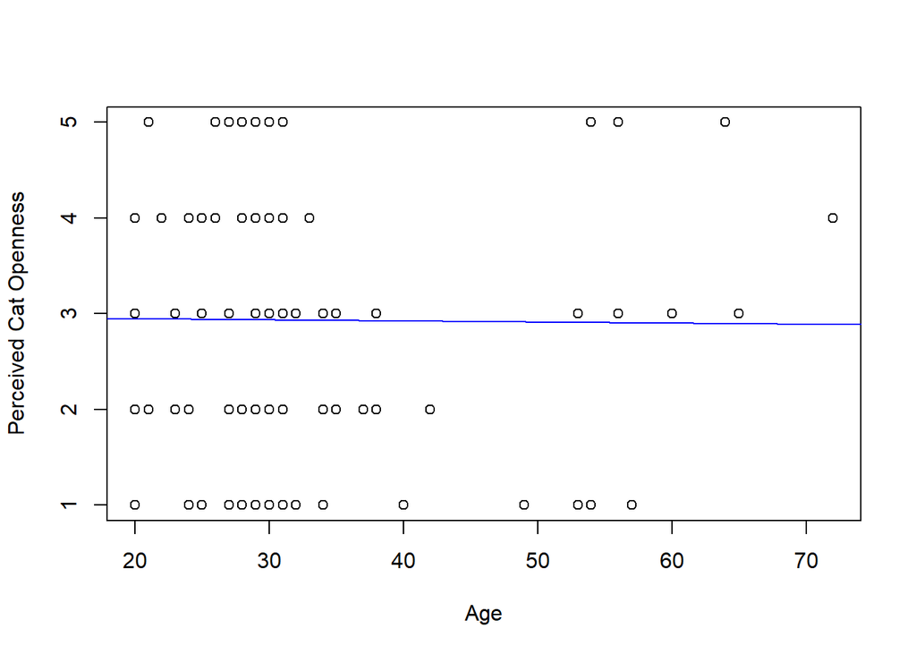

```r
plot(x = data$age,
     y = data$cat_open,
     xlab = "Age",
     ylab = "Perceived Cat Openness")

abline(lm(data$cat_open ~ data$age), col = "blue")
```

## Advanced analyses, etc.

# Conclusion

Well… that’s it. It was a lot, and not very in-depth, but you should now have a pretty good idea of how to clean/examine/analyze your data in the future!

Pretty soon, you too can fully exert your will on technology, much like the goal-scoring robot below.

[figure not shown]